# HW5

Eda Yildiz

January 6, 2019

## Multiple Instance Learning

In this exercise, we are given a dataset, namely Musk1. We are supposed to apply the multiple instance learning. The aim of multiple instance learning is to classify a bag given its instance characteristics In order to transform the instance-level information to bag-level representation following steps are applied.

Step 1: Clustering instances In order to cluster instances Kmedoids and Hierarchical clustering algorithms is used. As applyinbg these algorithmn two distance measure is used: eucledian and mannathan distance. Different number of clusters will be generated and their accuracies (for each distance measure, clustering algorithm and number of clusters) is reported.

Distances between the instances is calculated with the help of the “dist” function. The methods are specified as can be seen from below.

```r
    Dist=dist(Data, method = "eucledian")
    Dist=dist(Data, method = "manhattan")
```

In order to generate clusters by using k-medoid algorithm the function fastkmed is used. For the hierarchical clustering we firstly use hclust function, then cutree function is used.

Step Two: Center of the clusters are also available in the output of fastkmed function. The following code part is used to constuct the clusters. Because in the k-medoid algorithm the centroids are some instances itself the distance for each instance to the clusters are already calculated. Just filtering related rows enable us to obtain the distances. But in hierarahical clustering the function hclust and cutree do not provide center informations. We externally calculated the centers for each cluster.

```r
#K-medoids
Cluster=fastkmed(Dist, ncluster = k, iterate = 50)
Centroids=Cluster$medoid
Cluster=Cluster$cluster
InstanceDistance=Dist[Centroids,]
#Hierarchical Clustering

Cluster = as.data.table(cutree(hclust(as.dist(Dist),method="ward.D2"), k=k)) # get 5 clusters
HData=cbind(Data,Cluster)

#Center for the clusters are calculated as taking average of the instances in each cluster
Centroids=aggregate(HData[,3:168], list(HData$Cluster), mean)
DatawithCentroids=rbind(Data[,3:168],Centroids[,2:167])
#Distances for each instance to clusters are calculated
InstanceDistance=as.matrix (dist(DatawithCentroids,method=dist))
InstanceDistance=as.data.table(InstanceDistance)
InstanceDistance=InstanceDistance[477:.N,1:476]
```

Step Three: In order to represent the bag as the average of its instance distances to the cluster centroids following code part is used. For each bagId the distances of its instances to clusters are averaged.

```r
BagFeature=data.table()
for (i in 1:BagId)
{
  BagFeatureTemp= t(rowMeans(InstanceDistance[,BagIds==i]))
  BagFeature=rbind(BagFeature,BagFeatureTemp)
}
```

I defined the accuracy as the ratio of the number of bags clustered for all its instances in one cluster to the number of bags. Accuracies will be reported after explaining how lasso regression is applied.

I trained lasso logistic regression on the bag-level representation for classifying bags for Musk1 dataset. cv.lqa funtion is used as follows. For different lambda values 10 fold cross validation is applied. Afer obtaining the fitted values, prediction and performance functions are used to calculate TruePositiveRate and FalsePositiveRate. ROC curves and AUC values are calculated as shown in below.

```r
#run the logistic regression (binomial family for binary classification problem)
cvFused=cv.lqa(Classes,BagFeature2,lambda.candidates =list (c (0.001, 0.05, 1, 5, 10)), intercept = TRUE,
               family=binomial(), penalty.family= lasso,n.fold=10,loss.func = "dev.loss")

Predictors=round(cvFused$best.obj$fitted.values)
pred <- prediction(Classes, Predictors)

perf <- performance(pred,"tpr","fpr")

 auc <- performance(pred,"auc")
  auc <- unlist(slot(auc, "y.values"))
```

All the outputs of the asssignment are as follws. The accuracies for each distance measure, clustering algorithm and the number of clusters, ROC curves and AUC values are as follows.

```
## [1] "Kmedoids Accuracy for euclidean method and 2clusters is 0.5"
```

```
## [1] "Kmedoids Accuracy for manhattan method and 2clusters is 0.304347826086957"
## [1] "Kmedoids Accuracy for euclidean method and 4clusters is 0.423913043478261"
## [1] "Kmedoids Accuracy for manhattan method and 4clusters is 0.347826086956522"
## [1] "Kmedoids Accuracy for euclidean method and 6clusters is 0.239130434782609"
## [1] "Kmedoids Accuracy for manhattan method and 6clusters is 0.260869565217391"
## [1] "Kmedoids Accuracy for euclidean method and 8clusters is 0.434782608695652"
## [1] "Kmedoids Accuracy for manhattan method and 8clusters is 0.228260869565217"
```

```
## [1] "Kmedoids AUC for euclidean method and 2clusters is 0.652009456264775"
## [1] "Kmedoids AUC for manhattan method and 2clusters is 0.643333333333333"
## [1] "Kmedoids AUC for euclidean method and 4clusters is 0.643762183235868"
## [1] "Kmedoids AUC for manhattan method and 4clusters is 0.643762183235868"
## [1] "Kmedoids AUC for euclidean method and 6clusters is 0.771780303030303"
## [1] "Kmedoids AUC for manhattan method and 6clusters is 0.729047619047619"
## [1] "Kmedoids AUC for euclidean method and 8clusters is 0.815340909090909"
## [1] "Kmedoids AUC for manhattan method and 8clusters is 0.696795791487327"
```

```
## [1] "HierClst Accuracy for euclidean method and 2clusters is 0.597826086956522"
## [1] "HierClst Accuracy for manhattan method and 2clusters is 0.608695652173913"
## [1] "HierClst Accuracy for euclidean method and 4clusters is 0.597826086956522"
## [1] "HierClst Accuracy for manhattan method and 4clusters is 0.565217391304348"
## [1] "HierClst Accuracy for euclidean method and 6clusters is 0.597826086956522"
## [1] "HierClst Accuracy for manhattan method and 6clusters is 0.554347826086957"
## [1] "HierClst Accuracy for euclidean method and 8clusters is 0.554347826086957"
## [1] "HierClst Accuracy for manhattan method and 8clusters is 0.554347826086957"
```

```
## [1] "HierClst AUC for euclidean method and 2clusters is 0.685238095238095"
## [1] "HierClst AUC for manhattan method and 2clusters is 0.654088050314465"
## [1] "HierClst AUC for euclidean method and 4clusters is 0.872788139646102"
## [1] "HierClst AUC for manhattan method and 4clusters is 0.797115384615385"
## [1] "HierClst AUC for euclidean method and 6clusters is 0.850789096126255"
## [1] "HierClst AUC for manhattan method and 6clusters is 0.806791009086561"
## [1] "HierClst AUC for euclidean method and 8clusters is 0.838571428571429"
## [1] "HierClst AUC for manhattan method and 8clusters is 0.804935927859516"
```

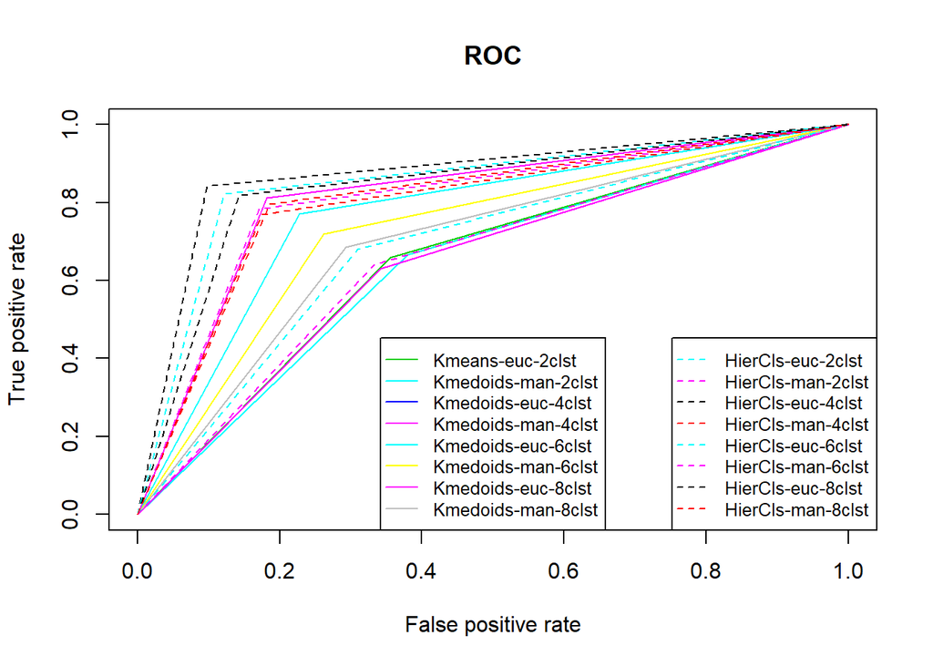

# Accuracy Comments

For the accuracy ratio I determined to measure the performances of all sets Hierarchical Clustering with Mannathan distance for 2 clusters gave the best results. Clearly we can see that hierarchical clustersng is better than the k-medoids algorithm. As the kmedoids accuracies are around 0.3, hierarchical clustering’s accuracies are around 0.6. Also we can say that most of the cases the eucledian distance gave better results.

# ROC-AUC Comments

As a result we can clearly see that hierarchical clustering > k-medoids and EucledianDistance > mannathan Distance.